# Assignment 5 - Visualization

Abhipsha Mahapatro

10:59pm, 21/11/2021

```r
# LOAD THE PACKAGES YOU ARE USING IN THIS CODE CHUNK
library(ggplot2)
library(tidyverse)
library(dplyr)
library(nycflights13)
library(ggrepel)
library(gridExtra)
library(grid)
library(reshape)
library(hrbrthemes)
library(readr)
library(viridis)
```

### Task 1 - Principles of good data visualization [10 points in total]

On [slide 75 of the lecture slides (“Dos and”Don’ts")](https://raw.githack.com/intro-to-data-science-21/lectures/main/07-visualization/07-visualization.html#85) you find a linked list of 20 statements expressing principles of good data visualization. Follow the links to learn more about them.

1. Select one of those principles and illustrate it as follows: [5 points]
1. Create a two-panel plot. The left panel shows a poorly designed plot (e.g., a 3D plot), the right panel shows a well-designed alternative using the same data. Note: check out [this vignette](https://cran.r-project.org/web/packages/egg/vignettes/Ecosystem.html) to learn how combine multiple plots into one plot. You are free to use whatever data you want to make your point.
2. The title of the plot should be: Number (according to the list) and name of the principle, e.g. “**18. Don’t go 3D.**”
3. The bottom of the plot should provide a note that explains, in a few sentences, the principle illustrated in the plot and how the right is an improved over the left version.
4. Embed the plot in your `.Rmd` but also provide it as a `.png` or `.pdf` in your submission repo.

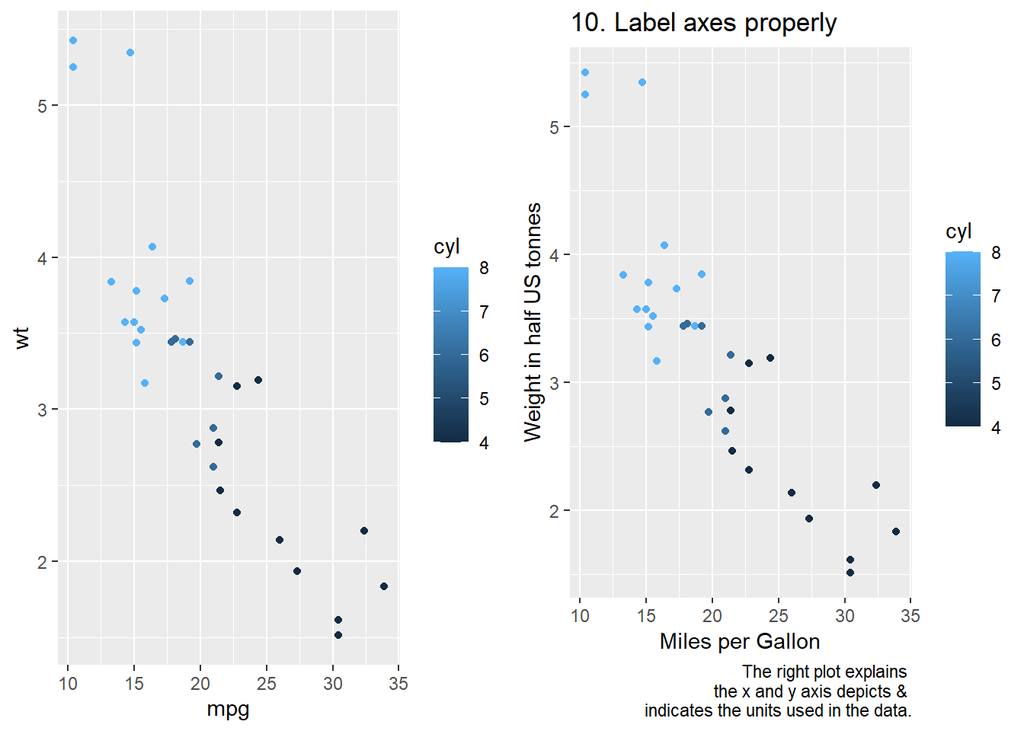

```r
# YOUR CODE HERE

# principle Use readable fonts and font sizes
p1 <- ggplot(mtcars, aes(mpg, wt, colour = cyl)) + geom_point()

p2<- ggplot(mtcars, aes(mpg, wt, colour=cyl)) + ggtitle("10. Label axes properly") + xlab("Miles per Gallon") + ylab("Weight in half US tonnes") + geom_point() +
  labs(caption = "The right plot explains
  the x and y axis depicts &
  indicates the units used in the data.")


gridExtra::grid.arrange(p1, p2, nrow = 1)
```

```r
#saving the plot

plotfinal <- arrangeGrob(p1, p2, nrow=1)
ggsave(file="Plot Labelling.pdf", plotfinal)
```

2. Now, come up with another principle of good data visualization **that is not listed on the slide** and illustrate it following the instructions in the previous task. [5 points]

```r
# YOUR CODE HERE

iris2 <- melt(iris, id.vars="Species")
iris2[1:3,]
```

|  | Species | variable | value |
| --- | --- | --- | --- |
| 1 | setosa | Sepal.Length | 5.1 |
| 2 | setosa | Sepal.Length | 4.9 |
| 3 | setosa | Sepal.Length | 4.7 |

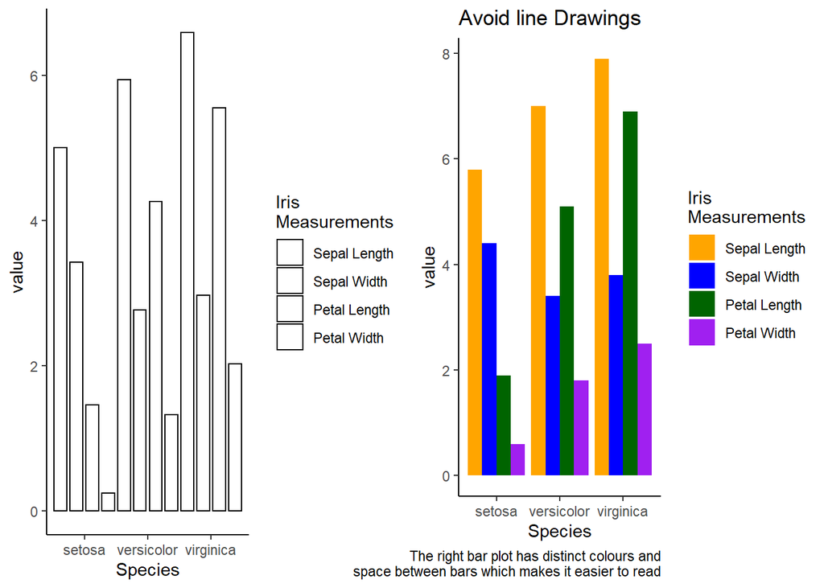

```r
bar1 <- ggplot(data=iris2, aes(x=Species, y=value, fill=variable))
bar11 <- bar1 + geom_bar(width = 0.8,stat="summary", position = position_dodge(width=1),colour="black")+
  scale_fill_manual(values=c("white","white","white","white"),
                    name="Iris\nMeasurements",
                    breaks=c("Sepal.Length", "Sepal.Width", "Petal.Length", "Petal.Width"),
                    labels=c("Sepal Length", "Sepal Width", "Petal Length", "Petal Width"))+theme_classic()

bar2 <- ggplot(data=iris2, aes(x=Species, y=value, fill=variable))
bar22<- bar2 + geom_bar(stat="identity", position = position_dodge()) +
  scale_fill_manual(values=c("orange", "blue", "darkgreen", "purple"),
                    name="Iris\nMeasurements",
                    breaks=c("Sepal.Length", "Sepal.Width", "Petal.Length", "Petal.Width"),
                    labels=c("Sepal Length", "Sepal Width", "Petal Length", "Petal Width"))+theme_classic()+
                    ggtitle("Avoid line Drawings")+
                    labs(caption = "The right bar plot has distinct colours and
                    space between bars which makes it easier to read")




gridExtra::grid.arrange(bar11, bar22, nrow = 1)
```

```r
#saving the plot
myplot <- arrangeGrob(bar11, bar22, nrow=1)
ggsave(file="Nolinegraphs.pdf", myplot)
```

### Task 2 - Life expectancy vs. health expenditure [6 points in total]

Over at [Our World in Data](https://ourworldindata.org/grapher/life-expectancy-vs-health-expenditure) you will find a chart illustrating life expectancy vs. health expenditure, 1970 to 2015, across countries.

1. Download the data and reproduce the plot as closely as possible using only the 2015 data (i.e. the bubble scatter plot that you see when you move the slider to the right) and linear scales. You can ignore the interactive features and are free in your choice of color scales and labels within the plotting area. [3 points]

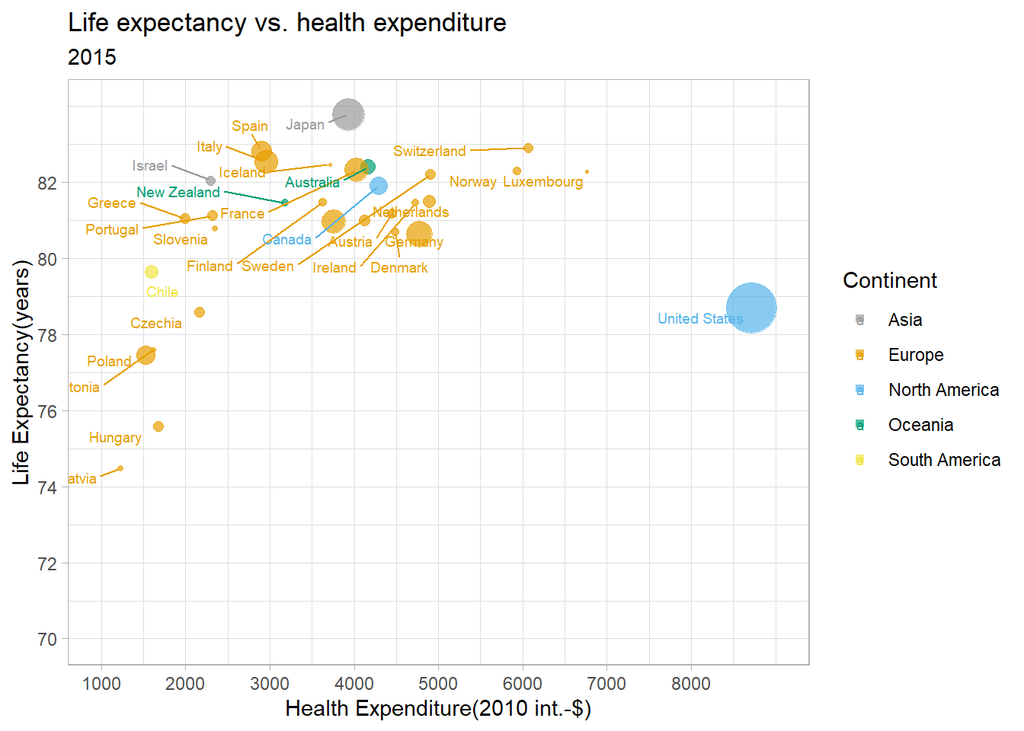

```r
# YOUR CODE HERE

data_lehe <- read_csv("life-expectancy-vs-health-expenditure.csv", col_types = list("Health Expenditure and Financing (per capita) (OECDstat (2017))" = col_character()))

#recode column names for ease
colnames(data_lehe)[which(names(data_lehe) == "Health Expenditure and Financing (per capita) (OECDstat (2017))")] <- "Health"
colnames(data_lehe)[which(names(data_lehe) == "Life expectancy at birth, total (years)")] <- "Life"
data_lehe$Pop <- data_lehe$`Population (historical estimates)`

data_lehe$Health <- as.numeric(data_lehe$Health)
data_lehe$Pop <- as.numeric(data_lehe$Pop)
data_lehe$Life <- as.numeric(data_lehe$Life)
data1 <- subset(data_lehe, data_lehe$Year==2015)
data1 <-subset(data1, Continent=="Asia"| Continent=="North America"| Continent=="South America"| Continent=="Europe"| Continent=="Oceania")

#add colourblind palatte
cbPalette <- c("#999999", "#E69F00", "#56B4E9", "#009E73", "#F0E442", "#0072B2", "#D55E00", "#CC79A7")


ggplot(subset(data1),
       aes(x = Health,
           y = Life,
           color = Continent,
           )) +
  geom_point(aes(size = Pop), alpha = 0.7) +
  geom_text_repel(aes(label=Entity),hjust=0, vjust=0, size = 2.5) +
  guides(size = "none", color = guide_legend(override.aes = list(shape = 15)))+
  scale_size(range = c(.1,24))+
   scale_colour_manual(values=cbPalette)+
  labs(title = "Life expectancy vs. health expenditure",
       subtitle = "2015",
       x = "Health Expenditure(2010 int.-$)",
       y = "Life Expectancy(years)")+
  scale_y_continuous(breaks = (seq(70,82,2)),limits = c(70,84))+
  scale_x_continuous(breaks = (seq(1000,8000,1000)), limits = c(1000,9000))+
  theme_light()
```

2. Using the complete dataset, reproduce the [connected scatter plot](https://clauswilke.com/dataviz/time-series.html) of the original chart. Again, you are free in your choice of color scales and labels within the plotting area. [3 points]

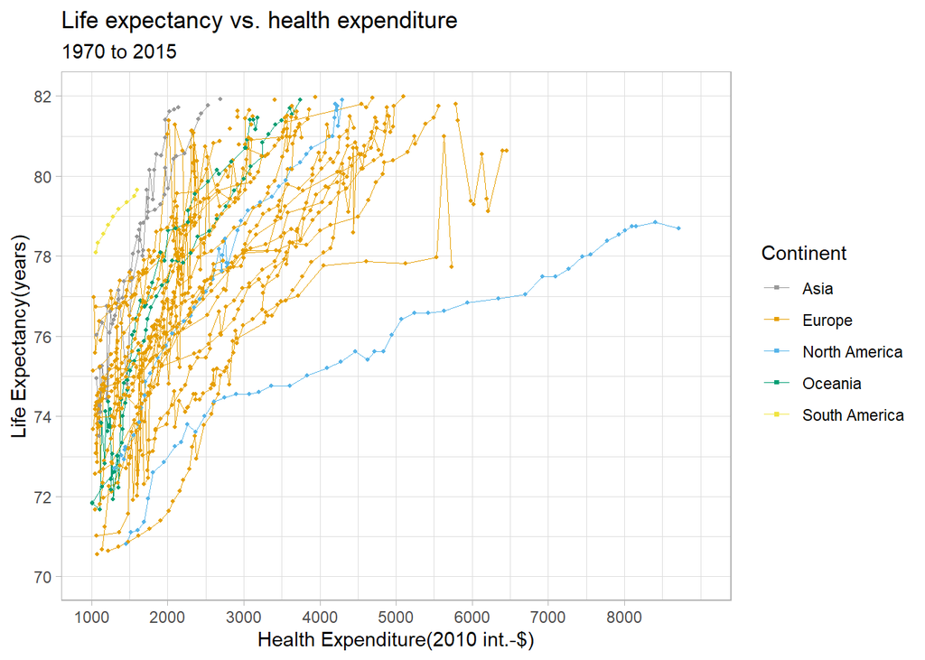

```r
# YOUR CODE HERE

data_2b <- subset(data_lehe, data_lehe$Year>1969)
data_2b <- subset(data_2b, select = c(Entity, Year, Health, Life, Continent))
data_2b$Continent[data_2b$Entity=="Germany"] <- "Europe"
data_2b$Continent[data_2b$Entity=="Poland"] <- "Europe"
data_2b$Continent[data_2b$Entity=="Netherlands"] <- "Europe"
data_2b$Continent[data_2b$Entity=="France"] <- "Europe"
data_2b$Continent[data_2b$Entity=="Greece"] <- "Europe"
data_2b$Continent[data_2b$Entity=="Hungary"] <- "Europe"
data_2b$Continent[data_2b$Entity=="Slovenia"] <- "Europe"
data_2b$Continent[data_2b$Entity=="Czechia"] <- "Europe"
data_2b$Continent[data_2b$Entity=="Portugal"] <- "Europe"
data_2b$Continent[data_2b$Entity=="Finland"] <- "Europe"
data_2b$Continent[data_2b$Entity=="Sweden"] <- "Europe"
data_2b$Continent[data_2b$Entity=="Switzerland"] <- "Europe"
data_2b$Continent[data_2b$Entity=="Luxembourg"] <- "Europe"
data_2b$Continent[data_2b$Entity=="Austria"] <- "Europe"
data_2b$Continent[data_2b$Entity=="Norway"] <- "Europe"
data_2b$Continent[data_2b$Entity=="Belgium"] <- "Europe"
data_2b$Continent[data_2b$Entity=="Estonia"] <- "Europe"
data_2b$Continent[data_2b$Entity=="Ireland"] <- "Europe"
data_2b$Continent[data_2b$Entity=="Denmark"] <- "Europe"
data_2b$Continent[data_2b$Entity=="Iceland"] <- "Europe"
data_2b$Continent[data_2b$Entity=="Spain"] <- "Europe"
data_2b$Continent[data_2b$Entity=="Italy"] <- "Europe"
data_2b$Continent[data_2b$Entity=="United Kingdom"] <- "Europe"

data_2b$Continent[data_2b$Entity=="Japan"] <- "Asia"
data_2b$Continent[data_2b$Entity=="Israel"] <- "Asia"

data_2b$Continent[data_2b$Entity=="Canada"] <- "North America"
data_2b$Continent[data_2b$Entity=="Mexico"] <- "North America"
data_2b$Continent[data_2b$Entity=="United States"] <- "North America"

data_2b$Continent[data_2b$Entity=="New Zealand"] <- "Oceania"
data_2b$Continent[data_2b$Entity=="Australia"] <- "Oceania"

data_2b$Continent[data_2b$Entity=="Chile"] <- "South America"

data_2b <-subset(data_2b, Continent=="Asia"| Continent=="North America"| Continent=="South America"| Continent=="Europe"| Continent=="Oceania")



ggplot(subset(data_2b),
       aes(x = Health,
           y = Life,
           color = Continent,
           group = Entity)) +
  geom_line(size = 0.3)+
  geom_point(size = 0.80) +
  guides(size = "none", color = guide_legend(override.aes = list(shape = 15)))+
  scale_size(range = c(.1,10))+
   scale_colour_manual(values=cbPalette)+
  labs(title = "Life expectancy vs. health expenditure",
       subtitle = "1970 to 2015",
       x = "Health Expenditure(2010 int.-$)",
       y = "Life Expectancy(years)")+
  scale_y_continuous(breaks = (seq(70,82,2)),limits = c(70,82))+
  scale_x_continuous(breaks = (seq(1000,8000,1000)), limits = c(1000,9000))+
  theme_light()
```

### Task 3 - IMDb small multiples [5 points in total]

The file [`imdb_series_df.csv`](https://github.com/intro-to-data-science-21/assignments/blob/main/assignment-5-setup/imdb_series_df.csv.zip?raw=true) contains a data set on rating information on series and episodes from the InternetMovieDatabase. Use these data to create a small multiples plot that illustrates a relationship of your choice. You can work with the entire dataset or a subset. Your plot should adhere to the principles of good design. In addition to the visualization, provide a brief discussion (10 sentences or less) of what the plot might tell us.

*Note:* The data binary is fairly large (~93MB). It makes sense to download it first to your local drive and then import it into R. However, make sure that the file is not synced to GitHub using `.gitignore`.

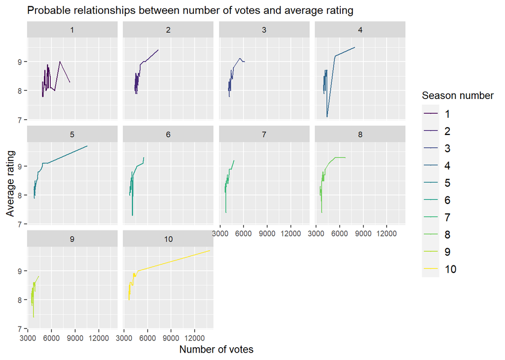

```r
# YOUR CODE HERE
#plot comedy shows by year

imdb <- read_csv("imdb_series_df.csv")

imdb <- subset(imdb, imdb$series_title=="Friends")
imdb <- subset(imdb, imdb$season_nr>=1 & imdb$season_nr<11)

ggplot(data = imdb,
        mapping = aes(x = num_votes ,
                      y = avg_rating,
                      color = as.factor(season_nr))) +
  geom_point(size=0.2) +
  geom_line() +
  scale_color_viridis_d() +
 facet_wrap(~ season_nr) +
   labs(x = "Number of votes", y = "Average rating",
        color = "Season number",
        title = "Probable relationships between number of votes and average rating") +
   theme(text = element_text(size = 10),
          plot.title = element_text(size = 11),
          axis.text=element_text(size=7.5),
          legend.text = element_text(size =11))
```

The plot above shows us the relationship between average rating and number of votes for the show called “Friends” which was first released in 1994. We look at this relationship for all 10 seasons of the show. We explore this relationship in particular as IMDB counts individual votes cast by viewers for the show and converts into a weighted average which they then use as ratings. By plotting this on a multiple graphs, we can see the popularity of the show, which seasons were better or worse and which episodes were liked better. The data points on these graphs are the episodes of each season. We notice that the maximum number of votes/rating is for the season finale at the end of the last ever episode of more than 12,000 votes, owing to the popularity of the show. The season finale with the seconf highest rating was of Season 5.